# Partial Least Squares Regression (PLSR) for Quantifying Coffee Adulteration: Spectral Preprocessing Using MSC, Savitzky-Golay, and Second Derivative

Author

Derick Malavi

## Introduction

Coffee adulteration, such as blending premium Arabica with lower-cost Robusta, undermines quality and authenticity, posing significant challenges for consumers, producers, and regulators. High-dimensional spectroscopic data, encompassing the full spectrum, provides valuable insights for detecting such fraud. However, the large number of variables requires advanced techniques to effectively model the data without overfitting.

```r
# Load libraries
warning = FALSE
  suppressWarnings(suppressMessages({
  library(caret)
  library(GA)
  library(viridis)
  library(Boruta)
  library(ggplot2)
  library(dplyr)
  library(readxl)
  library(readr)
  library(pls)
  library(janitor)
  library(class)
  library(MLmetrics)
  library(MLeval)
  library(themis)
  library(ROSE)
  library(parallel)
  library(doParallel)
  library(foreach)
  library(pheatmap)
  library(mdatools)
  library(nnet)
  library(DMwR)
  library(e1071)
  library(knitr)
  library(pROC)
  library(gridExtra)
  library(FactoMineR)
  library(doSNOW)
  library(MASS)
  library(factoextra)
  library(kernlab)}))
```

## Prepare Data

```r
# Load data: msc_sg_2d spectra

hsi_msc_sg_2d <- read.csv("coffee_ground_msc_sg_2d.csv")

# Ensure we have the same number of dimensions and the range of our columns/covariates
dim(hsi_msc_sg_2d)
```

```
[1] 1469  229
```

```r
# Check a few column names
col_check <- colnames(hsi_msc_sg_2d[,c(1:6)])
col_check
```

```
[1] "sample_id"     "binary_class"  "three_class"   "adult_percent"
[5] "cal_val"       "X935.609985"
```

```r
# our response variable (adulteration percentage) is column 4
# The spectral values start from column # 6 -------> 229

# Convert the adulteration percentage to numeric for compatibility with ML
hsi_msc_sg_2d$adult_percent <- as.numeric(hsi_msc_sg_2d$adult_percent)
```

## Get the X and y variables

```r
X <- hsi_msc_sg_2d[,c(6:229)]
y <- hsi_msc_sg_2d[,4]

class(y) #Ensure y (target variable) is a numeric for regression
```

```
[1] "numeric"
```

## Visualize X

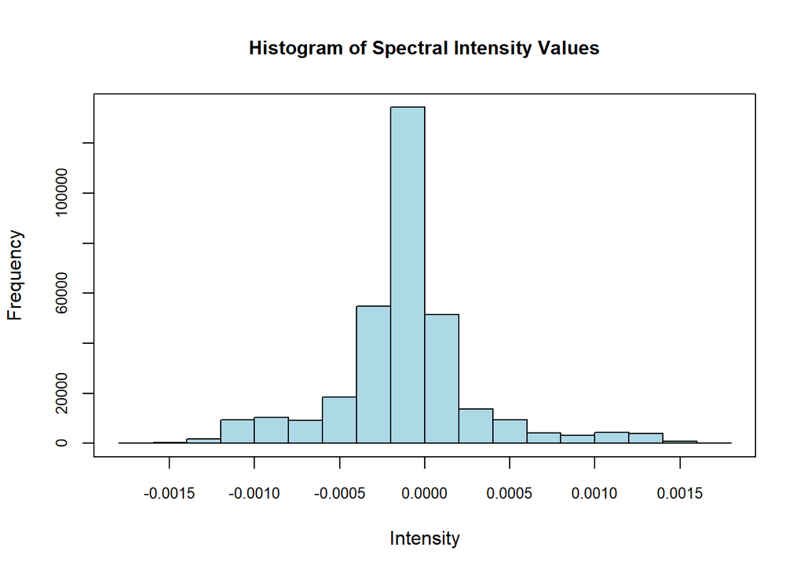

```r
hist(as.matrix(X), col = 'lightblue', cex.main = 1.0, cex.axis = 0.8,cex.lab = 1.0,
     main = 'Histogram of Spectral Intensity Values', xlab = 'Intensity'); box()
```

## Split the Data (Train_Test Split)

- We want to select features based on training data only to avoid any data leakage that could inflate model performance and make the model less generalizable to unseen data.

```r
# Subset samples for cross-validation and external validation (70/30)
# Record 1 under cal_val variable is for calibration while 2 will be for testing the model

sample<-hsi_msc_sg_2d$cal_val == 1

# Split to train and test sets
X_train <- X[sample,]
X_test <- X[!sample,]
y_train <-y[sample]
y_test <- y[!sample]

# Check length of the subsets for training and validation
dim(X_train)
```

```
[1] 1055  224
```

```r
dim(X_test)
```

```
[1] 414 224
```

```r
length(y_train)
```

```
[1] 1055
```

```r
length(y_test)
```

```
[1] 414
```

```r
# Merge the test and train data
train_data <- data.frame(y_train, X_train)
test_data <- data.frame(y_test, X_test)
```

## Check correlations by HeatMaps

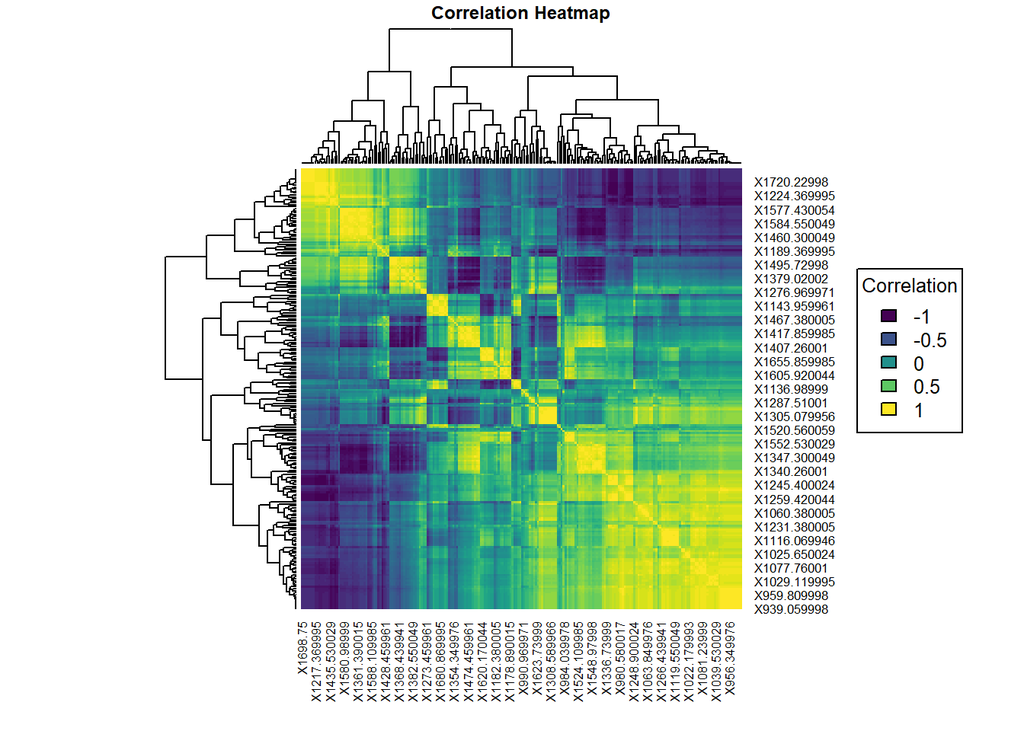

```r
#Calculate correlations
corr <- cor(train_data[,-1])

# Create a heat map
par(cex.main = 0.6)
heatmap(corr, symm = TRUE,
        col = viridis(50),
        main = "Correlation Heatmap")

# Add legend
legend("right",
       legend = seq(-1, 1, by = 0.5),  # Correlation range
       fill = viridis(5),
       title = "Correlation", cex = 0.8)
```

## Train Models

- We will train models based all spectral features

```r
# Set random seed for reproducibility
set.seed (123)

# Set up the training control(10 folds 10 times cross_validation)
control <- trainControl(method = "repeatedcv", number = 10, repeats = 10,
                        savePredictions = "final",
                        summaryFunction = defaultSummary,
                        selectionFunction = 'best', allowParallel = TRUE)

# We used oneSE for classification. For regression, we will use 'best': a model that minimizes RMSECV
```

```r
#Set the metric as accuracy
metric<-"RMSE"
```

```r
# Hyperparameter Tuning
# We will use tune Length to automatically determine the optimal number of PLS components
```

```r
set.seed(123)
#Register cluster for caret to train the models in parallel
cl<-makeCluster(6,type = "SOCK")
suppressWarnings(suppressMessages(
  registerDoSNOW(cl)))

# Start_time
start_time<-Sys.time()

#Train the model using cross-validation (10 folds, 10 times)
fit_pls_msc_sg_2d<-train(y = train_data[,1],
                         x = train_data[,-1],
                         method = 'pls', tuneLength = 60,
                         trControl = control,
                         metric = metric)
#End_time
end_time<-Sys.time()

model_training_time<-end_time-start_time

stopCluster(cl) # Stop the parallel run cluster

print(model_training_time)
```

```
Time difference of 16.56067 secs
```

```r
# Display regression results
print(fit_pls_msc_sg_2d)
```

```
Partial Least Squares

1055 samples
 224 predictor

No pre-processing
Resampling: Cross-Validated (10 fold, repeated 10 times)
Summary of sample sizes: 949, 949, 949, 948, 949, 950, ...
Resampling results across tuning parameters:

  ncomp  RMSE       Rsquared   MAE
   1     19.321065  0.5507700  15.109504
   2     17.622449  0.6261199  13.498552
   3     13.584317  0.7784938  10.698877
   4     12.409390  0.8161597   9.889478
```

[output cut: 59 more lines]

## Save the models for future use

```r
saveRDS(fit_pls_msc_sg_2d, "fit_pls_msc_sg_2d.rds")
```

## Plot the cross-validation results —–> Model Selection

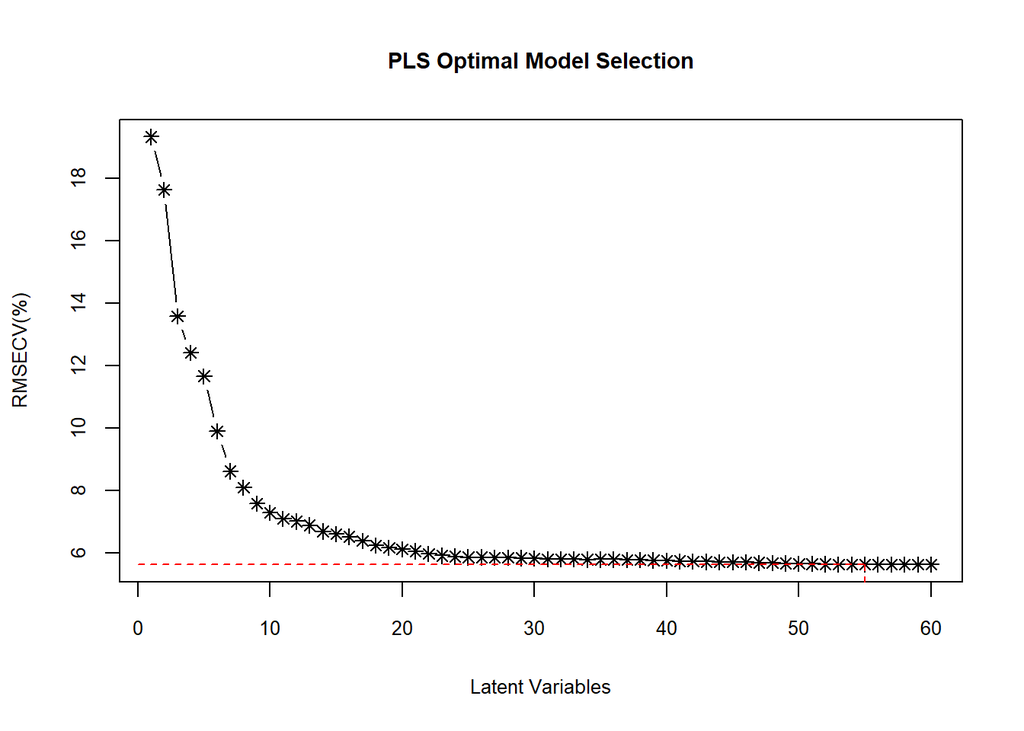

```r
# Imbalanced Data
pls_data <- fit_pls_msc_sg_2d$results
best_Lvs = fit_pls_msc_sg_2d$bestTune$ncomp
y_RMSE = pls_data$RMSE[pls_data$ncomp == best_Lvs]
plot(pls_data$ncomp,pls_data$RMSE, type = "b",col = "black",pch = 8,cex.axis = 0.8,
     xlab = "Latent Variables", ylab = "RMSECV(%)",cex.lab = 0.9,
     main = 'PLS Optimal Model Selection',
     cex.main = 0.9,
     cex.lab = 0.8)
# Add line from x-axis to the specific point
segments(x0 = best_Lvs, y0 = 0, x1 = best_Lvs, y1 = y_RMSE, col = "red", lty = 2)

# Add line from y-axis to the specific point
segments(x0 = 0, y0 = y_RMSE, x1 = best_Lvs, y1 = y_RMSE, col = "red", lty = 2)
```

## Display the cross-validation results

```r
print(paste('The optimal parameters for training the pls model is',
            fit_pls_msc_sg_2d$bestTune$ncomp, 'components'))
```

```
[1] "The optimal parameters for training the pls model is 55 components"
```

## Display CV Results in Tables

```r
kable(fit_pls_msc_sg_2d$results)
```

| ncomp | RMSE | Rsquared | MAE | RMSESD | RsquaredSD | MAESD |
| --- | --- | --- | --- | --- | --- | --- |
| 1 | 19.321065 | 0.5507700 | 15.109504 | 1.4042217 | 0.0591742 | 0.8864765 |
| 2 | 17.622449 | 0.6261199 | 13.498552 | 1.9987789 | 0.0777944 | 0.9077720 |
| 3 | 13.584316 | 0.7784938 | 10.698877 | 1.5171963 | 0.0461787 | 0.9116966 |
| 4 | 12.409390 | 0.8161597 | 9.889478 | 0.8999259 | 0.0247812 | 0.7098549 |
| 5 | 11.667546 | 0.8373620 | 9.321404 | 0.9268986 | 0.0234886 | 0.6703551 |
| 6 | 9.909189 | 0.8827765 | 7.969248 | 0.7509666 | 0.0166999 | 0.6301948 |
| 7 | 8.625880 | 0.9112546 | 7.032858 | 0.5421555 | 0.0099966 | 0.4808926 |
| 8 | 8.098625 | 0.9218566 | 6.496928 | 0.5517788 | 0.0097378 | 0.4732889 |
| 9 | 7.599293 | 0.9313151 | 6.108422 | 0.5473727 | 0.0086641 | 0.4472038 |
| 10 | 7.305765 | 0.9364653 | 5.798596 | 0.5386453 | 0.0082853 | 0.4378732 |
| 11 | 7.104227 | 0.9399601 | 5.607553 | 0.4827933 | 0.0072778 | 0.3996469 |
| 12 | 7.025114 | 0.9412474 | 5.529274 | 0.4830837 | 0.0073570 | 0.4006386 |
| 13 | 6.895758 | 0.9434342 | 5.387050 | 0.4626092 | 0.0068662 | 0.3903883 |
| 14 | 6.700089 | 0.9466294 | 5.265637 | 0.4394337 | 0.0065240 | 0.3776947 |
| 15 | 6.623060 | 0.9478971 | 5.203947 | 0.4324840 | 0.0061940 | 0.3652383 |
| 16 | 6.533350 | 0.9493946 | 5.124253 | 0.4214798 | 0.0059634 | 0.3548942 |
| 17 | 6.398818 | 0.9514244 | 5.033662 | 0.4103039 | 0.0057715 | 0.3311521 |
| 18 | 6.247877 | 0.9536592 | 4.902988 | 0.4081682 | 0.0057805 | 0.3319261 |
| 19 | 6.175627 | 0.9547094 | 4.853500 | 0.4064443 | 0.0056429 | 0.3351989 |
| 20 | 6.138219 | 0.9552580 | 4.835300 | 0.3934624 | 0.0054162 | 0.3258655 |
| 21 | 6.069264 | 0.9562773 | 4.782657 | 0.3715966 | 0.0050405 | 0.3260014 |
| 22 | 5.978742 | 0.9576340 | 4.717095 | 0.3659584 | 0.0048781 | 0.3134232 |
| 23 | 5.928033 | 0.9582789 | 4.672269 | 0.3810168 | 0.0050998 | 0.3212238 |
| 24 | 5.900227 | 0.9586976 | 4.651859 | 0.3703598 | 0.0049833 | 0.3242954 |
| 25 | 5.874190 | 0.9590674 | 4.633254 | 0.3809013 | 0.0050806 | 0.3243686 |
| 26 | 5.872403 | 0.9591121 | 4.629481 | 0.3835063 | 0.0050954 | 0.3214761 |
| 27 | 5.863896 | 0.9592588 | 4.629544 | 0.3685843 | 0.0048972 | 0.3005910 |
| 28 | 5.858373 | 0.9593776 | 4.655693 | 0.3585803 | 0.0048097 | 0.3000528 |
| 29 | 5.849362 | 0.9594883 | 4.661137 | 0.3523769 | 0.0047473 | 0.2888747 |
| 30 | 5.833941 | 0.9596960 | 4.638855 | 0.3580854 | 0.0048370 | 0.2935941 |
| 31 | 5.818480 | 0.9599249 | 4.627974 | 0.3494841 | 0.0047137 | 0.2794295 |
| 32 | 5.811538 | 0.9600463 | 4.617131 | 0.3444339 | 0.0046105 | 0.2728912 |
| 33 | 5.819536 | 0.9599442 | 4.621960 | 0.3365674 | 0.0045534 | 0.2667613 |
| 34 | 5.801636 | 0.9601998 | 4.631397 | 0.3297972 | 0.0044096 | 0.2651174 |
| 35 | 5.806587 | 0.9601151 | 4.643287 | 0.3246253 | 0.0043306 | 0.2661215 |
| 36 | 5.805332 | 0.9601310 | 4.651244 | 0.3241469 | 0.0043829 | 0.2719698 |
| 37 | 5.788477 | 0.9603467 | 4.640722 | 0.3261095 | 0.0043951 | 0.2696067 |
| 38 | 5.791675 | 0.9603135 | 4.637498 | 0.3327638 | 0.0044952 | 0.2718924 |
| 39 | 5.776132 | 0.9605034 | 4.620672 | 0.3416373 | 0.0046570 | 0.2749587 |
| 40 | 5.769947 | 0.9605894 | 4.626044 | 0.3510186 | 0.0048064 | 0.2790343 |
| 41 | 5.749593 | 0.9608679 | 4.617250 | 0.3536344 | 0.0048123 | 0.2730869 |
| 42 | 5.743093 | 0.9609469 | 4.616215 | 0.3562767 | 0.0048285 | 0.2744924 |
| 43 | 5.730235 | 0.9611275 | 4.611909 | 0.3560933 | 0.0048328 | 0.2741326 |
| 44 | 5.720671 | 0.9612576 | 4.596087 | 0.3549200 | 0.0048370 | 0.2737419 |
| 45 | 5.721163 | 0.9612594 | 4.587637 | 0.3581007 | 0.0049062 | 0.2750225 |
| 46 | 5.711909 | 0.9613922 | 4.578394 | 0.3533685 | 0.0048555 | 0.2682671 |
| 47 | 5.701088 | 0.9615403 | 4.565761 | 0.3537898 | 0.0048318 | 0.2702900 |
| 48 | 5.689557 | 0.9616875 | 4.551356 | 0.3549592 | 0.0048349 | 0.2680495 |
| 49 | 5.680609 | 0.9618001 | 4.545878 | 0.3588613 | 0.0048740 | 0.2701987 |
| 50 | 5.671622 | 0.9619114 | 4.537693 | 0.3588611 | 0.0049185 | 0.2700474 |
| 51 | 5.661772 | 0.9620467 | 4.530578 | 0.3573704 | 0.0048913 | 0.2692992 |
| 52 | 5.652901 | 0.9621613 | 4.521207 | 0.3562140 | 0.0049148 | 0.2711056 |
| 53 | 5.646731 | 0.9622367 | 4.516515 | 0.3579755 | 0.0049351 | 0.2703759 |
| 54 | 5.640904 | 0.9623061 | 4.514779 | 0.3620535 | 0.0050114 | 0.2695935 |
| 55 | 5.640256 | 0.9623100 | 4.514472 | 0.3622711 | 0.0050003 | 0.2670237 |
| 56 | 5.643259 | 0.9622693 | 4.516286 | 0.3632990 | 0.0050092 | 0.2685056 |
| 57 | 5.644669 | 0.9622537 | 4.515372 | 0.3580191 | 0.0049577 | 0.2675565 |
| 58 | 5.649401 | 0.9621803 | 4.518970 | 0.3586844 | 0.0049795 | 0.2667473 |
| 59 | 5.648664 | 0.9621963 | 4.517445 | 0.3589755 | 0.0049773 | 0.2696132 |
| 60 | 5.646647 | 0.9622223 | 4.512219 | 0.3588125 | 0.0049899 | 0.2708571 |

```r
# Select row for the optimal model
opt_row <- fit_pls_msc_sg_2d$results %>%
  filter(ncomp==fit_pls_msc_sg_2d$bestTune$ncomp)

kable(opt_row)
```

| ncomp | RMSE | Rsquared | MAE | RMSESD | RsquaredSD | MAESD |
| --- | --- | --- | --- | --- | --- | --- |
| 55 | 5.640256 | 0.96231 | 4.514472 | 0.3622711 | 0.0050003 | 0.2670237 |

## Test the model performance on test data

```r
#Predict on the test set
observed <- test_data$y_test
predictions <- predict(fit_pls_msc_sg_2d,newdata=test_data)

# Generate predictions
results <- postResample(predictions, observed)

print(results)
```

```
     RMSE  Rsquared       MAE
8.9970143 0.9198553 6.9993572
```

```r
RMSEP = results[[1]]
R2 = results[[2]]
MAE = results[[3]]

cat('The RMSEP for the model on external validation is:', RMSEP,'\n')
```

```
The RMSEP for the model on external validation is: 8.997014
```

```r
cat('The R Squared value for the model is:', R2,'\n')
```

```
The R Squared value for the model is: 0.9198553
```

```r
# Calculate Residual Predictive Deviation to check model performance

RPD = sd(observed)/RMSEP

print(paste('The RPD values for the model is', round(RPD,2)))
```

```
[1] "The RPD values for the model is 3.24"
```

## Visualizations

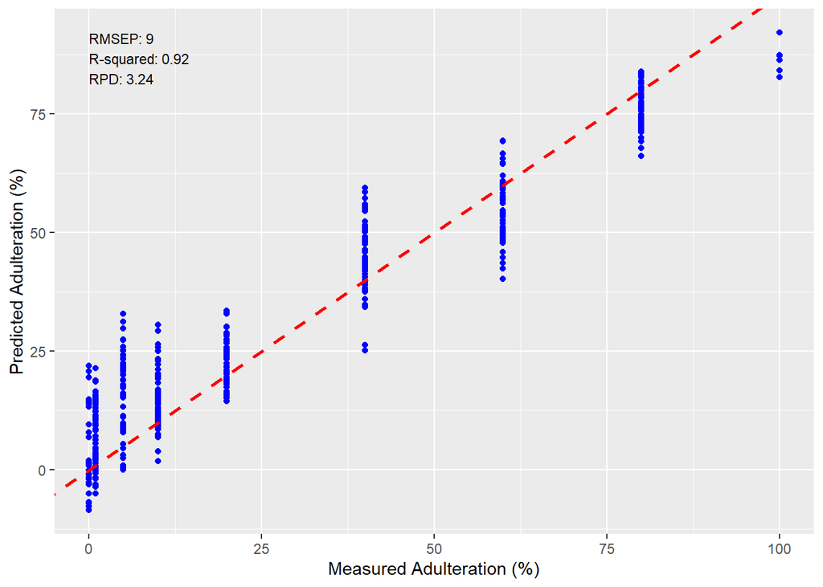

```r
# predicted vs observed line and scatter
# Create a data frame
results_df <- data.frame(observed=observed, predictions=predictions)

results_df %>%
  ggplot(aes(x = observed, y = predictions)) +
  geom_point(color = "blue") +
  geom_abline(slope = 1, intercept = 0, color = "red",
              linetype = "dashed", linewidth = 1) +
  labs( x = "Measured Adulteration (%)",
    y = "Predicted Adulteration (%)") +
  annotate("text",
    x = min(observed), y = max(predictions),
    label = paste("RMSEP:", round(RMSEP, 2),
      "\nR-squared:", round(R2, 3),
      "\nRPD:", round(RPD, 2)),
    hjust = 0, vjust = 1, size = 3, color = "black") +
  theme(
    axis.title = element_text(color = "black", size = 10),
    axis.text = element_text(color = "black"))+
  theme_gray()
```

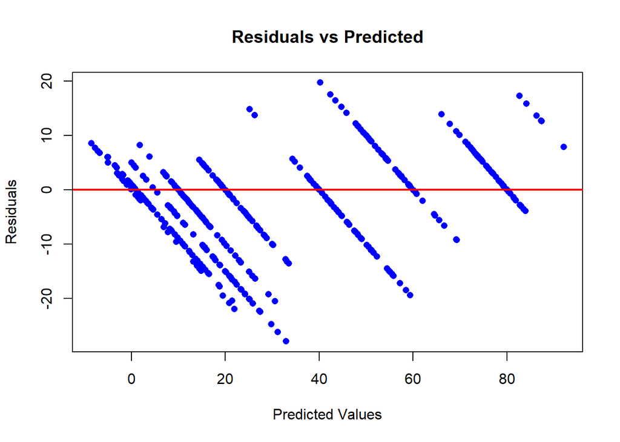

```r
# Check residuals

residuals <- observed - predictions

# Plot Residuals
plot(predictions, residuals,
     xlab = "Predicted Values",
     ylab = "Residuals",
     main = "Residuals vs Predicted",
     pch = 16, col = "blue")
abline(h = 0, col = "red", lwd = 2)
```

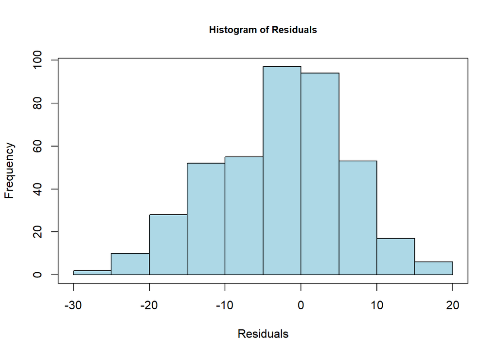

```r
hist(residuals,
     main = "Histogram of Residuals",
     xlab = "Residuals", cex.main = 0.8,
     col = "lightblue", border = "black"); box()
```

## Conclusion

- PLS demonstrate good performance in predicting adulteration in ground coffee. The model achieves an RPD value of 3.2.